| title: “A3: SPL Library Checkouts” |
| --- |
| output: html_document |

### Introduction

I chose to use the 2013-2023-5-Checkouts-SPL dataset, and then filter through to find all the checkouts of all Harry Potter series books, written by J. K. Rowling. I love the Harry Potter series, and my family started listening to the Harry Potter audiobooks during the summer of 2020, so I thought I could really personally connect to this data. I was also particularly curious at the trend in audiobook, ebook, and regular book checkouts and how they compare over the past ten years.

### The Dataset

The Seattle Public Library collected and published this data from what I can tell. For the data I chose to use, the dates included were the year and month, from January 2013 to January 2023. The kinds of books included audiobooks, ebooks, and regular books, but the data overall included all varied kinds of objects you can checkout from a library (movies, chargers, etc.). It also gave you general subjects within each item, with tags such as “juvenile fiction, wizards”, and other words that could be used to further subdivide the data. The data was collected to give the general public access to data that isn’t usually accessible. Most libraries don’t offer this kind of data. Some ethical questions we should consider when working with this data is am I using this data in a way that is helpful to others? Another question that I don’t think can be answered is if there was any personal information also collected with each checkout. It’s an ethical question for the library: how much personal information is collected when this data is collected? Some possible limitations with this data is that there is no date, and some books have different titles despite ultimately being the same book. For example, Harry Potter and the Sorcerer’s Stone is listed as a different book than “Harry Potter and the Sorcerer’s Stone: Harry Potter Series, Book 1”, which is ultimately the same book just with different phrasing of the title. I also have no way to measure how accurate or reliable this data is.

### Graphic 1: Scatter Line Plot

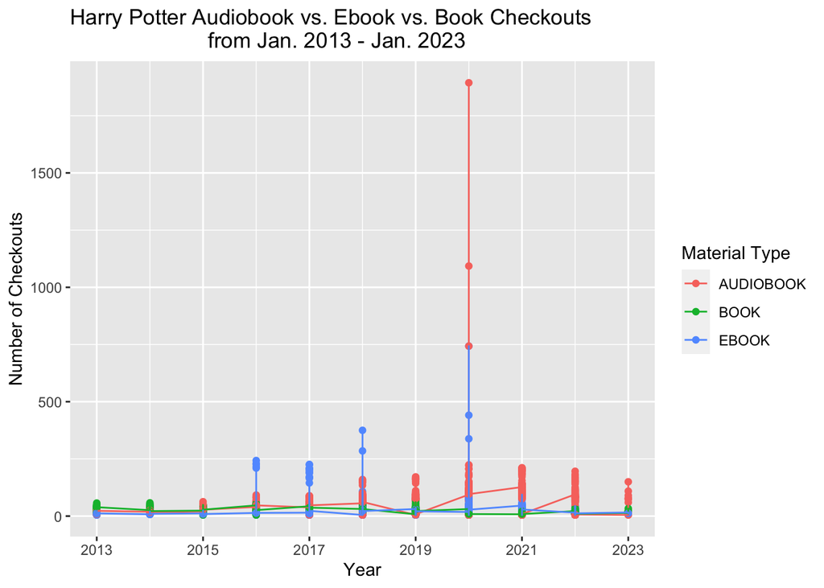

### Graphic 2: Pie Chart

I included this graphic after the first because I truly believe it’s a great way visual in understanding just how significant audiobooks have become. An astounding 53.6% of Harry Potter books that were checked out were audiobooks! If you think about it, audiobooks are a great way to multitask. You can listen while doing busybody jobs like cooking, cleaning, sitting around, drawing, etc. Then again, this data could have also been skewed by that one spike that we saw in the first graphic in April of 2020. I think that checkout must have been for a school district’s online English curriculum. However, compared to the first chart, I think this pie chart offers fresh insight. In the first chart, I believed that ebooks overall had a greater number of checkouts over the years, but with this pie chart visual you can see that books actually had a higher percentage of checkouts over the years. This could mean one of two things: one, while ebooks have been on the rise, books still have a consistent amount of subscribers, or two, ebooks became popular around 2016-2017, and books simply have more years of data for regular customers than ebooks do.

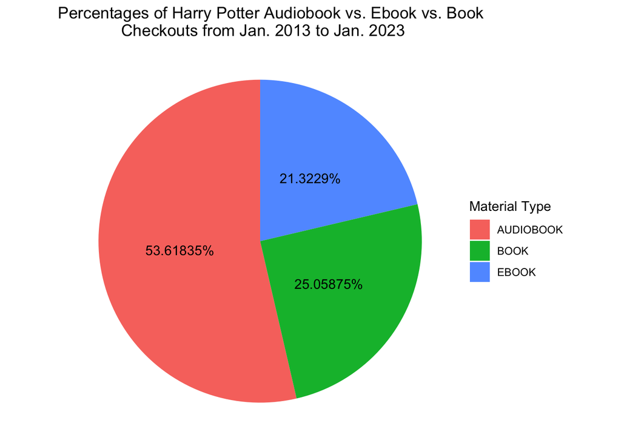

### Graphic 3: Scatter Line Plot

I included this simple graphic because of the first two graphics. I wanted to see, on its own, the audiobook trends to determine if the numbers have truly been on the rise or if there was some kind of skewed number. With this chart we can see much more clearly that there was a dramatic spike in 2020 (when COVID hit), and then the trend has been generally lowered back down to normal after 2020. I think for future analysis, I would like to compare a giant graph of a monthly record of checkouts between audiobook, ebook, and book. I would also love to analyze each of the books within the Harry Potter series and which of them were each of the three material types.

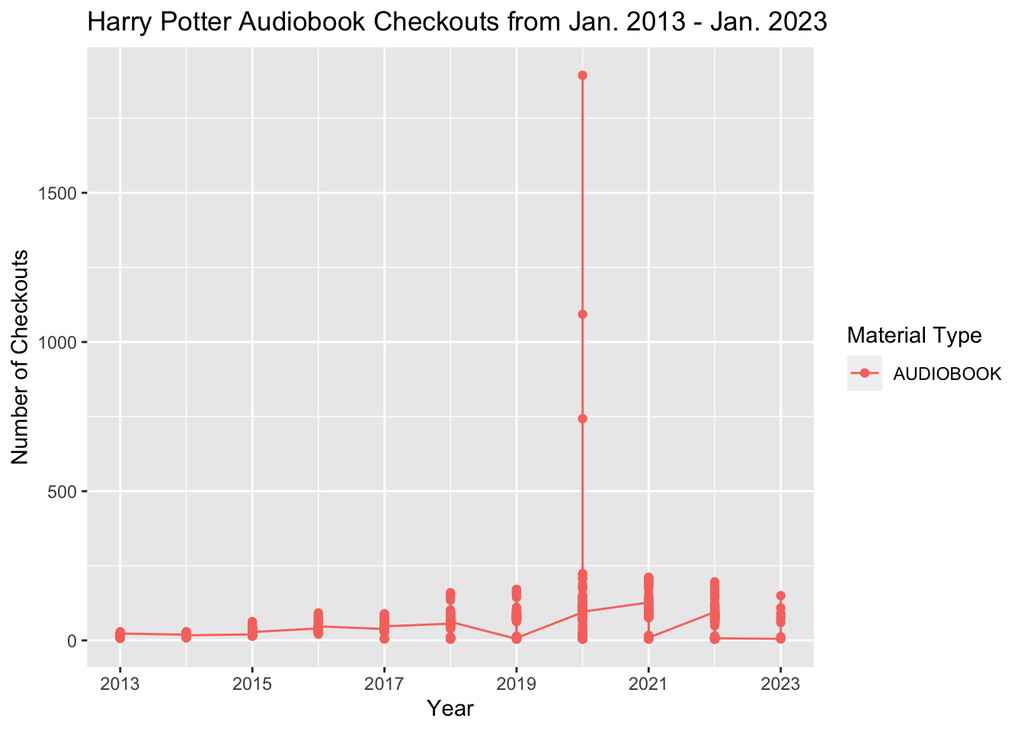